# Processing nanoARG JSON files in Python

In this tutorial you will learn the structure of the JSON file that can be downloaded from nanoARG for each individual sample as well as basic analysis of the data in the file.

In this tutorial you will learn:

- Identify the SCHEMA of the JSON file
- How to manipulate JSON files from nanoARG
- Produce simple visualizations

## JSON SCHEMA

JSON denotes Java Script Object Notation, a structure-based file that provides a human readable access to the data information.

nanoARG JSON contains all the results from each individual sample. To start, lets import the dependencies. Make sure you have installed the following modules.

```python
from ggplot import *
from scipy import stats
import json
import pandas as pd
```

### Load the JSON file

In this tutorial we will use one of our WWTP analyzed samples ('che_inf_raw.json' see paper for details)

```python
data = json.load(open('che_inf_raw.json'))
```

### Explore the content of the JSON file

The nanoARG JSON file consists of an array of five positions. Each position contains a particular information from the sample as follows:

- **data[0]:** Contains the **reads** with at least one ARG
- **data[1]:** Contains the nodes and edges needed for the **network** visualization
- **data[2]:** ARGs identified in the sample and colors used in the visualizations (for internal use in nanoARG)
- **data[3]:** Counts of each **taxa** identified in the sample
- **data[4]:** Several **general data** including: total number of reads, total number of mapped ARG reads, others.

In the next sections we will describe in detail each one of the fields.

### Reads field (data[0])

```python
display(pd.DataFrame(data[0][2]['read']))
display(pd.DataFrame(data[0][2]['data']))
```

|  | args | color | filter_read | fngs | genes | id | label | len | mges | mrgs | taxa | taxa_id | taxa_match_length | taxa_rank | taxa_score | taxa_species |
| --- | --- | --- | --- | --- | --- | --- | --- | --- | --- | --- | --- | --- | --- | --- | --- | --- |
| 0 | 2 | black | True | 0 | 2 | 493747fc-3f15-43aa-a43f-2e383c684495_template | 493747fc-3f15-43aa-a43f-2e383c684495_template | 3938 | 0 | 0 | Proteobacteria | 40214 | 28 | species | 169.0 | Acinetobacter johnsonii |

|  | arg | arg_class | arg_id | bitscore | block_id | color | coverage | end | evalue | identity | origin | position | score | start | strand | stroke_width | total_reads |
| --- | --- | --- | --- | --- | --- | --- | --- | --- | --- | --- | --- | --- | --- | --- | --- | --- | --- |
| 0 | adeJ | multidrug | NC_011586.7045444.p01 | 93.6 | 493747fc-3f15-43aa-a43f-2e383c684495_template | #84f331 | 0.445180 | 3722 | 4.500000e-19 | 31.0 | 1 | 3131 | 0.696730 | 2541 | + | 1 | 470976 |
| 1 | adeK | multidrug | NC_011586.7045445.p01 | 92.0 | 493747fc-3f15-43aa-a43f-2e383c684495_template | #84f331 | 0.762397 | 2028 | 1.300000e-18 | 32.2 | 1 | 1542 | 0.797756 | 1057 | + | 1 | 470976 |

By traversing the reads file you can build operon-like visualizations of your reads, or to check for gene patterns by taking a look at the "data" section.

### Network field (data[1])

This object contains two keys **nodes** and **edges**. Nodes are individual genes/taxas and edges represent co-occurrence, that means, if two genes are found in the same read, both nodes are linked.

Using pandas we can get that informacion in a much more comprehensive way. Let's build a table with source and target, useful for using other network analysis platforms such as cytoscape.

```python
pd.DataFrame([i['data'] for i in data[1]['edges']])[:20]
```

|  | color | id | source | source_origin | target | target_origin | weight |
| --- | --- | --- | --- | --- | --- | --- | --- |
| 0 | #42f47a | integrase_aadA | integrase | 2 | aadA | 1 | 2 |
| 1 | black | others_ompR | others | 4 | ompR | 1 | 1 |
| 2 | blue | Proteobacteria_abeS | Proteobacteria | 10 | abeS | 1 | 1 |
| 3 | #42f47a | transposon_transposase | transposon | 2 | transposase | 2 | 1 |
| 4 | blue | Actinobacteria_integrase | Actinobacteria | 10 | integrase | 2 | 7 |
| 5 | blue | Proteobacteria_macA | Proteobacteria | 10 | macA | 1 | 4 |
| 6 | black | Iron_ompR | Iron | 4 | ompR | 1 | 1 |
| 7 | #42f47a | recombinase_others | recombinase | 2 | others | 4 | 2 |
| 8 | #94f337 | msrE_mphD | msrE | 1 | mphD | 1 | 3 |
| 9 | blue | Proteobacteria_mdfA | Proteobacteria | 10 | mdfA | 1 | 15 |
| 10 | blue | Proteobacteria_penA | Proteobacteria | 10 | penA | 1 | 2 |
| 11 | blue | Proteobacteria_rpoB2 | Proteobacteria | 10 | rpoB2 | 1 | 8 |
| 12 | blue | Proteobacteria_Cobalt | Proteobacteria | 10 | Cobalt | 4 | 11 |
| 13 | blue | Proteobacteria_truncated putative response reg... | Proteobacteria | 10 | truncated putative response regulator ArlR | 1 | 1 |
| 14 | #f47756 | aph(6)-I_cat chloramphenicol acetyltransferase | aph(6)-I | 1 | cat chloramphenicol acetyltransferase | 1 | 1 |
| 15 | blue | Chordata_transposase | Chordata | 10 | transposase | 2 | 1 |
| 16 | #42f47a | transposase_Cadmium | transposase | 2 | Cadmium | 4 | 1 |
| 17 | black | Iron_kdpE | Iron | 4 | kdpE | 1 | 1 |
| 18 | #94f337 | macB_oprM | macB | 1 | oprM | 1 | 2 |
| 19 | black | Silver_truncated putative response regulator ArlR | Silver | 4 | truncated putative response regulator ArlR | 1 | 1 |

### Taxa field (data[3])

This field contains the information for the taxonomy annotation for the sample. To visualize the information that is being retrieved by nanoARG about the taxonomy annotation, let's use pandas to generate a table:

```python
pd.DataFrame(data[3])[:20]
```

|  | genome_size | name | num_reads | tax_id | tax_rank |
| --- | --- | --- | --- | --- | --- |
| 0 | 3238442024 | Homo sapiens | 25917 | 9606 | species |
| 1 | 4081329 | Acinetobacter johnsonii | 23920 | 40214 | species |
| 2 | 5196935 | Acidovorax sp. KKS102 | 7393 | 358220 | species |
| 3 | 2649137 | Moraxella osloensis | 5843 | 34062 | species |
| 4 | 4574859 | Acidovorax sp. RAC01 | 4309 | 1842533 | species |
| 5 | 11595472 | Acinetobacter baumannii | 3855 | 470 | species |
| 6 | 5163189 | Bacteroides vulgatus | 3691 | 821 | species |
| 7 | 4953232 | Alicycliphilus denitrificans | 2668 | 179636 | species |
| 8 | 4585154 | Acidovorax sp. JS42 | 2634 | 232721 | species |
| 9 | 5695231 | Comamonas testosteroni | 2619 | 285 | species |
| 10 | 6817856 | Variovorax paradoxus | 2371 | 34073 | species |
| 11 | 5310365 | Bacteroides dorei | 2238 | 357276 | species |
| 12 | 2962453 | Acinetobacter sp. TTH0-4 | 2212 | 1646498 | species |
| 13 | 7739252 | Aeromonas hydrophila | 2004 | 644 | species |
| 14 | 3796573 | Acidovorax ebreus | 1850 | 721785 | species |
| 15 | 4493411 | Ramlibacter tataouinensis | 1797 | 94132 | species |
| 16 | 6767514 | Delftia acidovorans | 1637 | 80866 | species |
| 17 | 22457305 | Pseudomonas aeruginosa | 1613 | 287 | species |
| 18 | 7195716 | Delftia tsuruhatensis | 1591 | 180282 | species |
| 19 | 6888188 | Pseudomonas putida | 1540 | 303 | species |

This table contains useful information such as: the genome size of the taxa (can be used for normalizing the reads accoring to the length of the hosted genome), the number of nanopore reads with that taxa, the NCBI taxonomy ID, the name of the taxa and the rank of the taxa (*phylum, order, species, etc*)

### Overal data of the Sample data[4]

This object contains basic information of the sample such as total number of reads or the read's distribution. Let's use pandas to see what is inside this object:

```python
pd.DataFrame(data[4])[:1]
```

|  | read_length_distribution | total_arg_reads | total_bp_counts | total_functional_reads | total_mapped_ARG_reads | total_reads | total_unique_genomes |
| --- | --- | --- | --- | --- | --- | --- | --- |
| 0 | [262665, 157680, 44424, 5474, 575, 111, 23, 7,... | 594 | 77628001 | 3475 | 564 | 470976 | 678 |

As we can see this object contains basic information regarding the analysis done in nanoARG.

## Visualizations

Now that we have explored what is inside the JSON file, we can create simple visualizations of the data

## Read length distribution

In this plot we are showing the distribution of the lenght of the nanopore reads in the sample

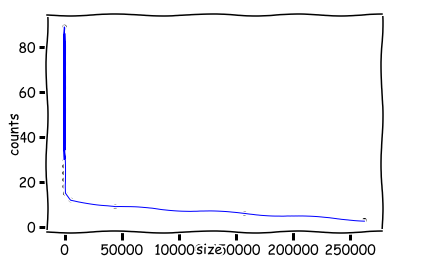

```python
read_length_data = pd.DataFrame(dict(size= data[4]['read_length_distribution'][0], counts=data[4]['read_length_distribution'][1]))
p = ggplot(read_length_data, aes(x='size', y='counts'))
p + geom_line(alpha=1, color='blue')
p + geom_point(alpha=1, color='black')
p + theme_xkcd()
```

### Compare alignment quality bewteen two datasets

In this section we are comparing the quality in sequence alignment between two different samples. In this case, we are looking at the effect of correction in the raw reads. This example is useful if you want to compare if two samples are giving you the same alignment quality for ARGs.

```
Ttest_indResult(statistic=-1.214600920168949, pvalue=0.22711927055137807)
```

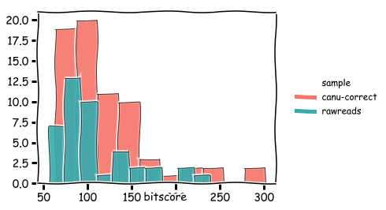

```python
# Get only ARGs
def subset(reads, identity=90, coverage=0.9, prob=0.9):
    for read in reads:

        for gene in read['data']:
            if gene['origin'] == 1:
                gene['arg_id'] = gene['metadata'][0]
                gene['arg_class'] = gene['metadata'][3]
                gene['arg'] = gene['metadata'][4]

                del gene['metadata']
                del gene['value']

                if gene['identity']>=identity and gene['coverage']>=coverage and gene['score']>=prob:
                    yield gene


data = json.load(open('che_inf_raw.json'))
reads = data[0]
raw = [ i for i in subset(reads, identity=20)]
raw = pd.DataFrame(raw)
raw['sample'] = 'rawreads'

data = json.load(open('che_inf_canu_corrected.json'))
reads = data[0]
canu = [ i for i in subset(reads, identity=20)]
canu = pd.DataFrame(canu)
canu['sample'] = 'canu-correct'


sx = pd.concat([raw, canu])
sx.index.name = 'index'
sx.to_csv('quality_alignments.csv')

# t test for distributions
print(stats.ttest_ind(raw['bitscore'],canu['bitscore']))

p = ggplot(sx, aes(x='bitscore', group='sample', fill='sample'))
p + geom_histogram(alpha=0.7, color='black')
p + theme_xkcd()
```